# 词序和谐在领属语这里断掉

TidyTuesday · 2026-11-03 (Week 44)

作者

zlZayn

发布于

2026年11月3日

# 四种修饰语，一个关于「谁站在名词哪一侧」的问题

Grambank 把每种语言的语法拆成 195 个是非题。其中四个问的是同一件事的不同版本：**这个修饰语站在名词的前面还是后面**——数词（GB024）、指示词（GB025）、属性词（GB193）、领属语（GB065）。取值 `1` 是在名词前，`2` 是在名词后，`3` 是两种顺序都行。

如果「语序类型」是个真东西，这四个答案应该彼此贴合；如果它们各走各的，那么这个说法就得打折扣。本报告就查这一件事。

2,467 种语言 × 195 个特征 = 481,065 个可能的格子，实际有编码的 362,025 个，覆盖率 75.3%。缺口不是「没有这个特征」，而是「没编到」——表示「不清楚」的 `?` 在清洗时已删除，所以空缺只代表调查没覆盖。

数据的底色偏冷：242,782 个编码是 `0`（67.1%），160 个特征在不到一半的语言里出现过，中位出现率 26.4%，最高的一个才 94.1%。覆盖也不均匀：一种语言被编码的特征数中位数 159 个，只有 36 种拿到全部 195 个，54 种不到 50 个。**任何「全世界语言都怎样」的句子，后面都得补一句「在这份样本里」。**

表 1 在四个语序参数之外多列了量词（GB203）——它只在下面的和谐阶梯里用到，正文的配对比较没有它。

表 1: 四个语序参数的编码分布（分母 2,467 种语言）

| 参数 | 修饰语 | 在名词前 | 在名词后 | 两侧都行 | 不作定语 | 未编码 |
| --- | --- | --- | --- | --- | --- | --- |
| GB024 | Numeral | 881 | 1087 | 231 | 0 | 217 |
| GB025 | Demonstrative | 921 | 1066 | 272 | 0 | 157 |
| GB193 | Property word | 514 | 1237 | 321 | 45 | 299 |
| GB065 | Possessor | 1040 | 879 | 403 | 0 | 94 |
| GB203 | Quantifier | 584 | 795 | 144 | 31 | 862 |

# 近一半语言把四个修饰语放在同一侧

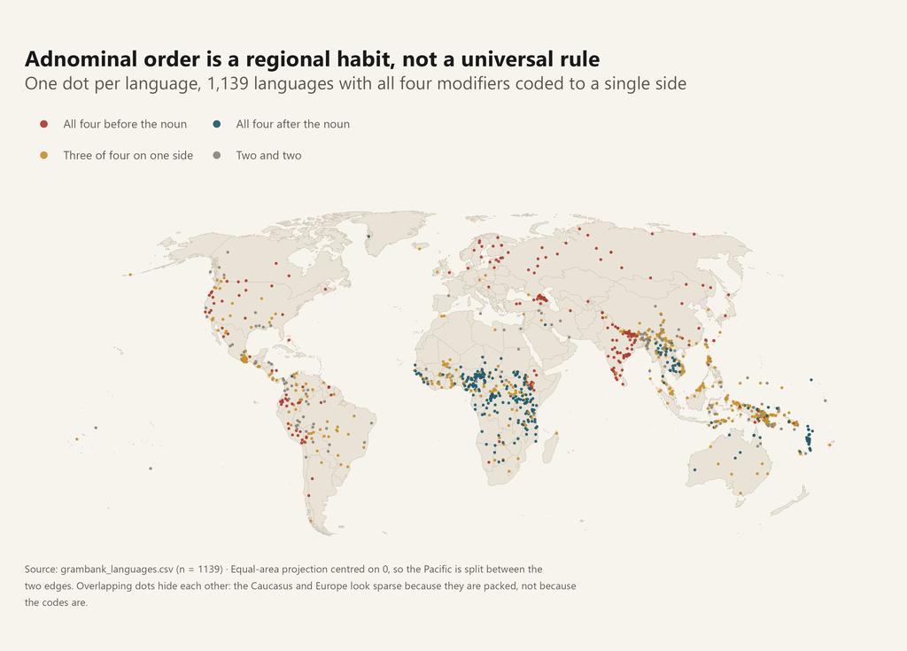

图 1: Where the four modifiers sit relative to the noun. Two coherent blocks — pre-noun Eurasia, post-noun Africa — and a wide ochre band where exactly one modifier crosses over.

严格口径下，四个参数都只有一个答案的语言有 1,139 种，占「至少编了一个」的 47.2%。被请出去的主要是「两种顺序都行」：数词一项就有 231 种语言拿到 3，这类语言在任何「同不同侧」的统计里必须先摘掉——否则「都行」会被读成「跨过去」，而它其实是「不适用这一问」。

在留下的 1,139 种语言里，四个修饰语全在同一侧的有 532 种：全前 233、全后 299，合计 46.7%。